# Análisis de patrones puntuales

Modificando: Jazmin Morales| Autores: Alberto Porras | Camilo Caudillo |

15 DE JULIO 2024

## Introducción

En la Ciudad de México tenemos un [portal de datos abiertos](https://datos.cdmx.gob.mx/pages/home/) en donde se encuentran una buena cantidad de registros sobre diferentes aspectos de la misma, nos interesan reportes de cosas que sucedieron en el espacio, descargamos la tabla de [hechos de tránsito](https://datos.cdmx.gob.mx/dataset/hechos-de-transito-reportados-por-ssc-base-ampliada-no-comparativa), que en la fecha de descarga (cerca de julio de 2024) contenía 139479 registros.

Durante 2023 se registraron 500 hechos de tránsito en la Alcaldía Cuahtémoc, de los cuales 333 se concentran en sólo 4 colonias, trabajaremos con esos puntos a los que añadimos algo de ruido aleatorio por los errores inducidos en la ubicación por la geocodificación, al final un punto quedó fuera del límite de las colonias por el ruido inducido.

## Cargar bibliotecas

Necesitaremos las bibliotecas [`spatstat`](https://cran.r-project.org/web/packages/spatstat/index.html) para el análisis de patrones puntuales, [`sf`](https://cran.r-project.org/web/packages/sf/vignettes/sf1.html) para la gestión de las capas espaciaes y [`dplyr`](https://dplyr.tidyverse.org/) para manipulación de tablas.

```r
library(spatstat)
library(sf)
library(dplyr)
```

## Cargar datos

Nuestro shape de los accidentes y las colonias que hemos seleccionado para el ejercicio tienen proyecciones diferentes, las colonias están en coordenadas geográficas, para tener distancias correctamente, necesitamos proyectar esta capa, la función `st_transform(32614)` proyecta la capa a coordenadas UTM14N. En R para combinar capas en mapas o cualquier análisis es indispensable que todas las capas tengan la misma proyección.

Al cargar la capa de los puntos vemos que es plana, sólo tiene dimensiones XY; los polígonos, por otro lado, tienen además Z.

## Procesar datos espaciales

Tenemos dos capas, una de polígonos y la otra con nuestros eventos, podemos crear un mapa sencillo.

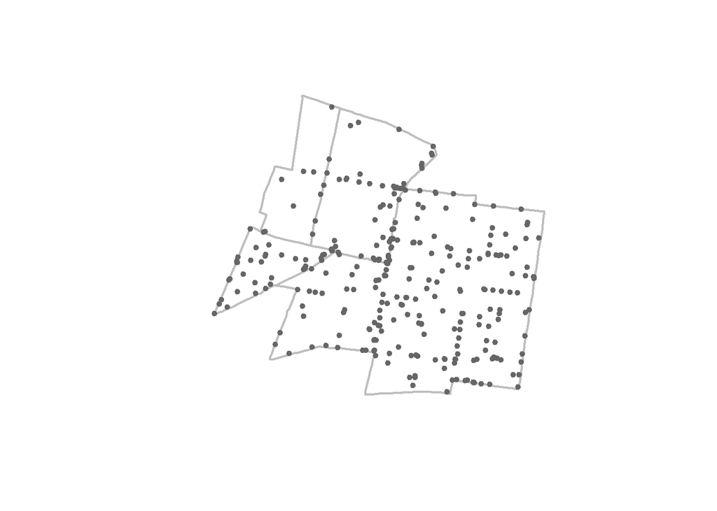

El polígono comprende cuatro zonas postales, necesitamos definir la ventana de observación como un sólo objeto envolvente.

### Disolver los polígonos

La biblioteca `sf` se integra a `dplyr`, por lo que podemos combinar el operador *pipe ‘|>’ o ‘%>%’* con otros verbos de manipulación de tablas, `summarize` nos sirve para realizar la combinación de las colonias en un sólo polígono, operación llamada en los SIG *dissolve*. Después necesitamos limpiar la capa, los errores en las intersecciones convierten en *POLYGONZ* a un polígono que debería ser plano, para regresarlo, necesitamos eliminar el valor de la altitud (Z) con `st_zm()` y por último quedarnos únicamente con el polígono

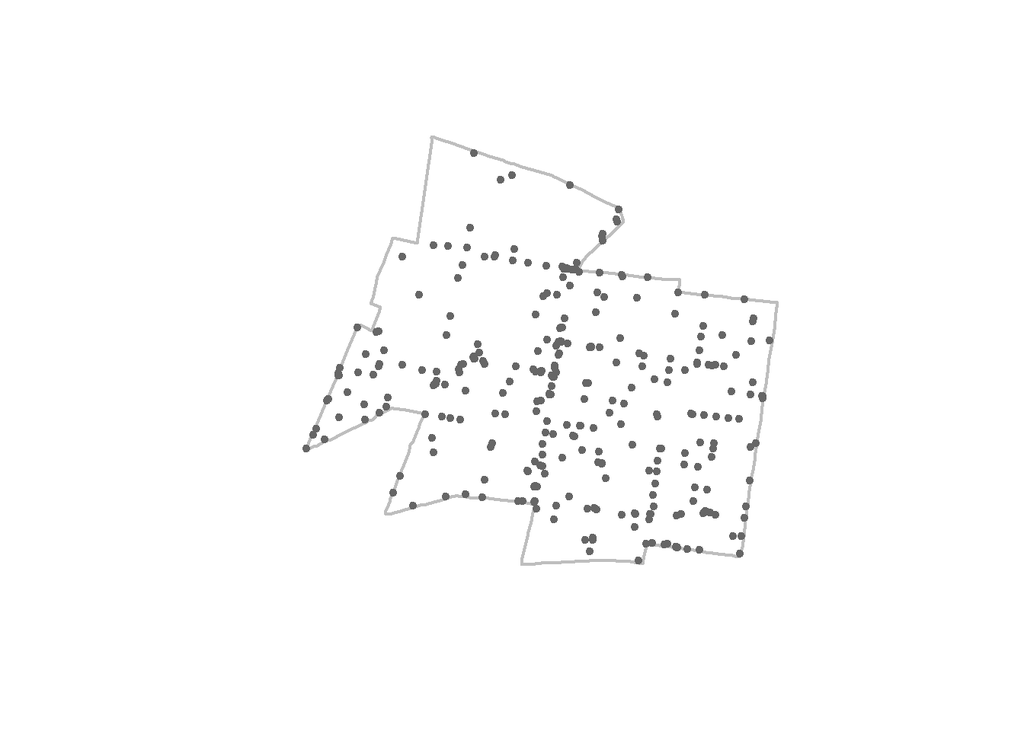

```r
pol <- cols |>
  summarize()|>
  st_zm() |>          #elimina la dimension Z
  st_cast("POLYGON")  # quedarnos con solo oligonos
plot(st_geometry(pol), lwd = 2, border = "gray")
plot(st_geometry(acc_23), pch = 20, col = "gray40",add = TRUE)
```

## Creación de un objeto ppp

Retomando los supuestos que nos permiten hacer estadística con los puntos, todo sucede en un plano, toda el área tiene la misma probabilidad de ocurrencia de un evento, y cada evento es independiente. Esto se traduce en que se requieren los pares de coordendas de cada evento, una zona de estudio bien definida y que los eventos no se sobrepongan.

Para crear un objeto de clase ppp, se requieren por lo menos dos elementos:

- Las coordenadas de los puntos
- Una ventana de obervación (la zona de estudio)
- Alternativamente podemos añadir marcas (atributos)

```r
cnd <- st_coordinates(acc_23) # Crear objeto con las coordenadas

owin_col <- as.owin(pol) #Coerciona  el polígono de las colonias a objeto "owin"

ppp_acc <- ppp(cnd[,1], cnd[,2], window = owin_col, unitname=c("metre","metres")) # Creación del objeto ppp, con unidades en metros
summary(ppp_acc) # Extrae un resumen del objeto ppp, nótese el parámetro de intensidad
```

```
## Planar point pattern:  332 points
## Average intensity 4.140982e-05 points per square unit
##
## Coordinates are given to 10 decimal places
##
## Window: polygonal boundary
## single connected closed polygon with 222 vertices
## enclosing rectangle: [483212.2, 487069.9] x [2147551.4, 2151044.2] units
##                      (3858 x 3493 units)
## Window area = 8017420 square units
## Fraction of frame area: 0.595
```

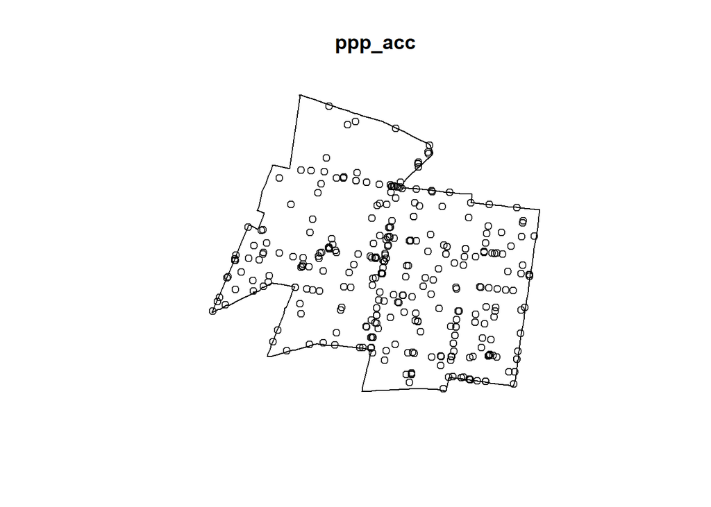

```r
plot(ppp_acc)
```

La intensidad $\lambda$ es muy pequeña, apenas 4.140982e-05 puntos por metro cuadrado

## Análisis con base en la intensidad

### Estimación de densidad de kernel

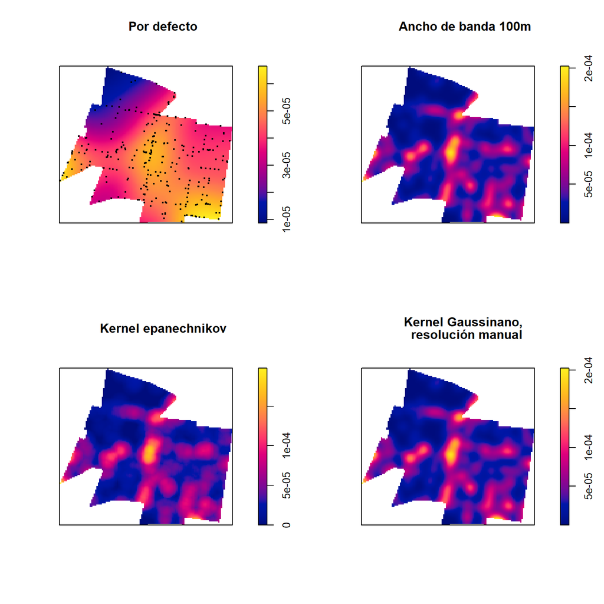

```r
par(mfrow=c(2,2))
plot(density(ppp_acc), main = "Por defecto")  # Opción por defecto, muy suavizado
points(ppp_acc, pch = 20, cex = 0.5)    #puso los puntos sobre la capa
plot(density(ppp_acc, sigma=100), main = "Ancho de banda 100m") # La opción por defecto es kernel = "gaussian"
plot(density(ppp_acc, sigma=100, kernel = "epanechnikov"), main = "Kernel epanechnikov") # Cambio de forma de la función
dg <- density(ppp_acc, sigma=100, kernel = "gaussian", ep = 10) # De nuevo con función Gaussiana y resolución de pixeles
plot(dg, main = "Kernel Gaussinano, \n resolución manual")
```

### Prueba de cuadrantes

En la prueba de cuadrantes, el supuesto básico es que la intensidad se descompone de forma que el valor esperado sólo depende del área de cada cuadrante.

```r
qtb <- quadrat.test(ppp_acc, nx = 5, ny= 5) # Prueba de cuadrantes básica en una malla de 5 por 5 divisiones
qtb
```

```
##
##  Chi-squared test of CSR using quadrat counts
##
## data:  ppp_acc
## X2 = 59.114, df = 22, p-value = 6.039e-05
## alternative hypothesis: two.sided
##
## Quadrats: 23 tiles (irregular windows)
```

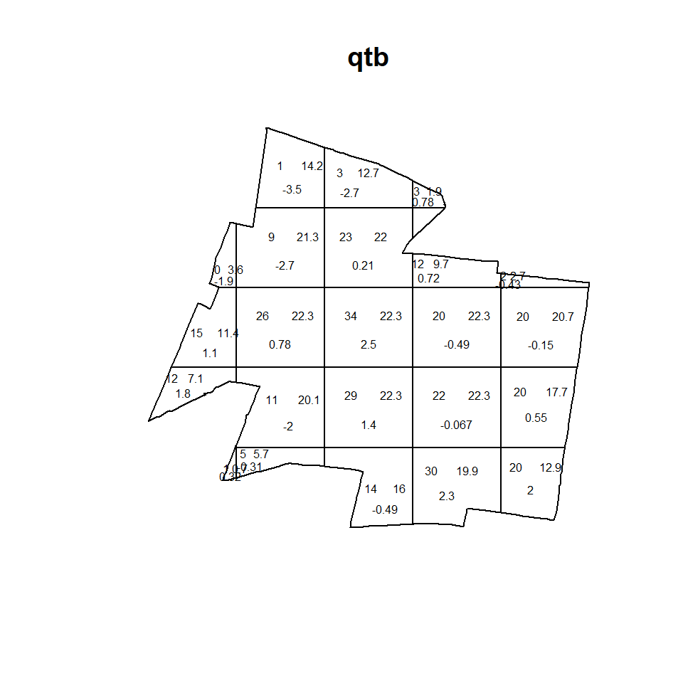

```r
plot(qtb, cex = 0.5)
```

> ¿Ves los diferentes numeros en el mapa?  
> El valor ubicado arriba a la izquierda es la cantidad de puntos que hay (observados), a la derecha están los valores esperados (teóricos) y abajo al centro están los residuales de Pearson, el signo indica si hay más o menos de los esperados.

Ahora necesitamos algunos argumentos extras para la función `quadrat.test()`, podemos hacer una prueba más específica declarando la hipótsis alternativa, en nuestro caso buscamos contrastar el proceso aleatorio completo contra el proceso aglomerativo, para ello usamos `alternative = "clustered"`, también necesitamos declarar el método deseado y la cantidad de simulaciones, es decir la cantidad de realizaciones para la prueba, esta parte es `method = "MonteCarlo", nsim = 999`

```r
quadrat.test(ppp_acc, nx = 5, ny= 5,
             alternative = "clustered",
             method = "MonteCarlo", nsim = 999)
```

```
##
##  Conditional Monte Carlo test of CSR using quadrat counts
##  Test statistic: Pearson X2 statistic
##
## data:  ppp_acc
## X2 = 59.114, p-value = 0.001
## alternative hypothesis: clustered
##
## Quadrats: 23 tiles (irregular windows)
```

Ahora, en lugar de rechazar la hipótesis nula $H_{0}: \text{El patrón puntual es consistente con un proceso aleatorio compleo}$ con sólo una comparación de la distribución chi-cuadrada con 22 grados de libartad, acumulamos 1000 estadísticos de contraste respecto a realizaciones de un proceso poisson homogéneo.

## Análisis con base en distacias

Cuando tenemos eventos, la información más basica con la que contamos son únicamente las coordenadas y la delimitación de la zona de estudio. Existen varias funciones para caracterizar un patrón puntual plano, partiendo de la función acumulativa de la distancia al vecino más cercano y las derivaciones más complejas de ésta.

## K de Ripley

La **K de Ripley** es la función de estructura de segundo orden más utilizada, indica el valor esperado de la cuenta de eventos dado un conjunto de distancias euclidianas.

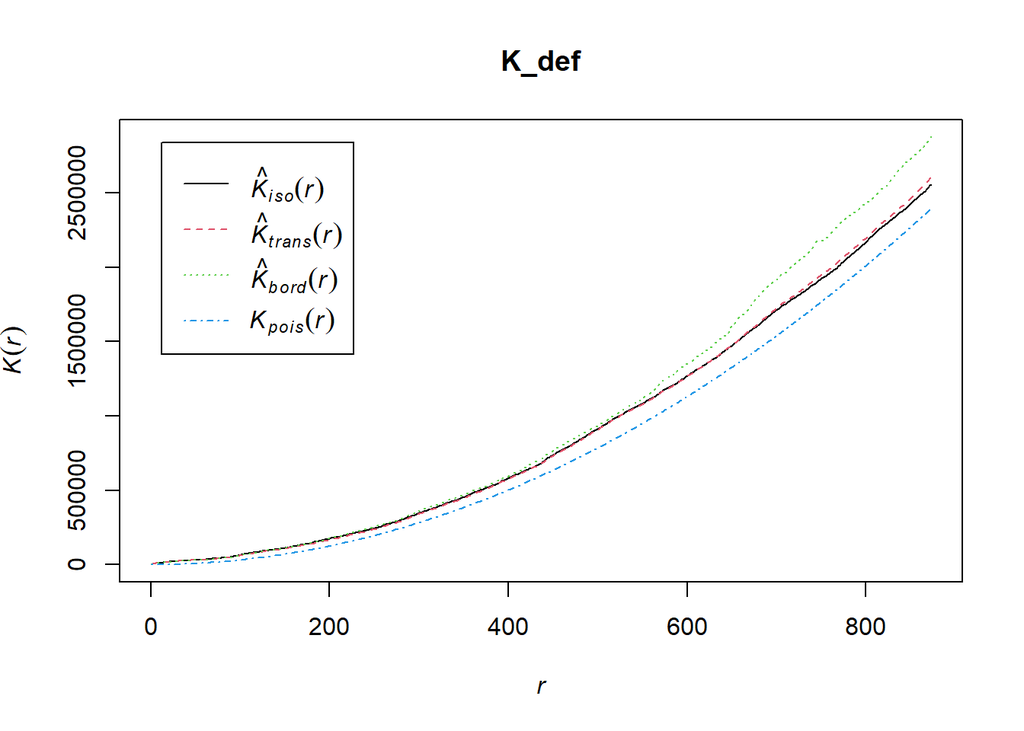

```r
K_def <- Kest(ppp_acc) # La opción por defecto nos muestra el crecimiento cuadrático convencional
plot(K_def)
```

La curva azul muestra el proceso Poisson homogéneo (o aleatoriedad espacial completa aec) que es la distribución teórica esperada, las línea verde y la roja son la función estimada con alguna corrección de los efectos de borde. Una desventaja de esta representación es que resulta difícil identificar diferencias entre los datos observados y esperados en los rangos más pequeños. Otra desventaja es que de nuevo el contaste con la distribución Poisson homogénea teórica puede ser muy fácil de rechazar dado que nos interesan rangos de distancias (**r**) en los que la línea observada se desvía por arriba (evidencia de aglomeración) o por abajo (evidencia de regularidad) del proceso aleatorio completo. El primer problema se puede corregir transformando la función de referencia en una línea horizontal $-\pi \times r^2$, a continuación se muestra su aplicación:

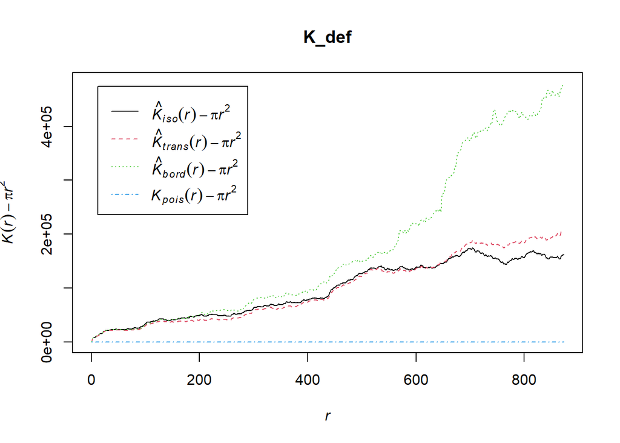

```r
plot(K_def,
     . - pi * r ^ 2 ~ r) # Transforma todos los resultados restando pi*r^2
```

El segundo problema se enfrenta de nuevo con ¡simulación Monte Carlo!, se aplica el mismo principio que en la prueba de cuadrantes, con base en el parámetro de intensidad $\lambda$ se genera una realización del aec y se almacena el resultado, esto se repite cierta cantidad de veces, por lo menos 999, lo que genera una región consistente con un proceso aleatorio completo, que nos indica cuando el patrón observado es consistente con la aleatoriedad espacial.

```r
set.seed(150)
K_env <- envelope(ppp_acc, Kest, correction = "border", nsim = 999)
```

[output not shown]

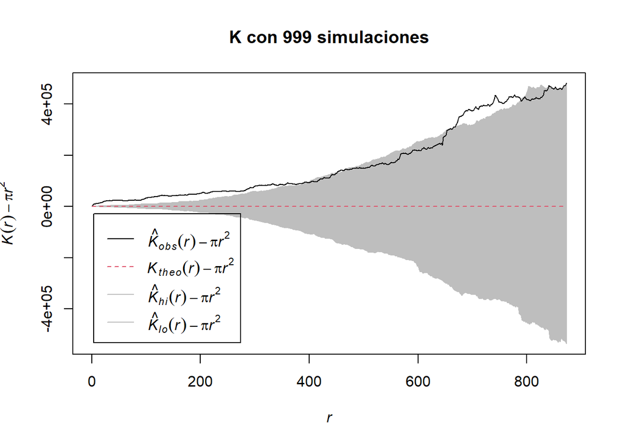

```r
plot(K_env,. - pi * r ^ 2 ~ r, main = "K con 999 simulaciones")
```

Ahora tenemos un resultado más interesante, ahora la región gris nos muestra la envovente de las simulaciones, consistentes con un proceso Posisson homogéneo, la línea negra es la función estimada en nuestro patrón puntual plano, hay dos regiones en las que se separa de la envolvente, de 0 a 400 metros y después de los ~700 a los 800 metros. Esto nos indica que dentro de esos rangos de distancias es altamente probable que encontremos cúmulos.